# Tesla stock price before and after the US Presidential Election 2024

## Introduction

In this exercise, I aim to examine Tesla's stock price movements one week before and after the U.S. Presidential Election on November 5, 2024.

Elon Musk, the owner of Tesla, has been a prominent supporter of Donald Trump, the winner of the election. Tesla's stock price could serve as an indicator of public confidence in Trump’s victory and his ability to govern. A logical expectation would be a rise in Tesla's stock price following Trump's win. However, I am also interested in exploring how long this trend persisted and whether the stock price reflected public confidence in Trump's chances before the election.

## Methods

I extracted the stock information of Tesla from the API of Marketstack. I analyzed the closing prices of Tesla between Oct 29 and Nov 12.

```python
import requests
import json

url = "https://api.marketstack.com/v1/eod?access_key=ed2fc352b82bafa55b9e6c9b576dd8b4"

querystring = {"symbols":"TSLA","date_from":"2024-10-29", "date_to":"2024-11-12"}

response = requests.get(url, params=querystring)

print(response.json())
```

[output not shown]

```python
import pandas as pd
import matplotlib.pyplot as plt

# Parse the JSON response
data = response.json()

# Extract "close" and "date" values
records = data["data"]
close_dates = [{"date": record["date"], "close": record["close"]} for record in records]

# Convert to a DataFrame
df = pd.DataFrame(close_dates)
print(df)
```

```
                        date   close
0   2024-11-12T00:00:00+0000  328.49
1   2024-11-11T00:00:00+0000  350.00
2   2024-11-08T00:00:00+0000  321.22
3   2024-11-07T00:00:00+0000  296.91
4   2024-11-06T00:00:00+0000  288.53
5   2024-11-05T00:00:00+0000  251.44
6   2024-11-04T00:00:00+0000  242.84
7   2024-11-01T00:00:00+0000  248.98
8   2024-10-31T00:00:00+0000  249.85
9   2024-10-30T00:00:00+0000  257.55
10  2024-10-29T00:00:00+0000  259.52
```

```python
# Transform the date format to MM-DD
df['date'] = pd.to_datetime(df['date']).dt.strftime('%m-%d')
print (df)
```

```
     date   close
0   11-12  328.49
1   11-11  350.00
2   11-08  321.22
3   11-07  296.91
4   11-06  288.53
5   11-05  251.44
6   11-04  242.84
7   11-01  248.98
8   10-31  249.85
9   10-30  257.55
10  10-29  259.52
```

```python
# Sort the order by date
df = df.sort_values(by='date')
print(df)
```

```
     date   close
10  10-29  259.52
9   10-30  257.55
8   10-31  249.85
7   11-01  248.98
6   11-04  242.84
5   11-05  251.44
4   11-06  288.53
3   11-07  296.91
2   11-08  321.22
1   11-11  350.00
0   11-12  328.49
```

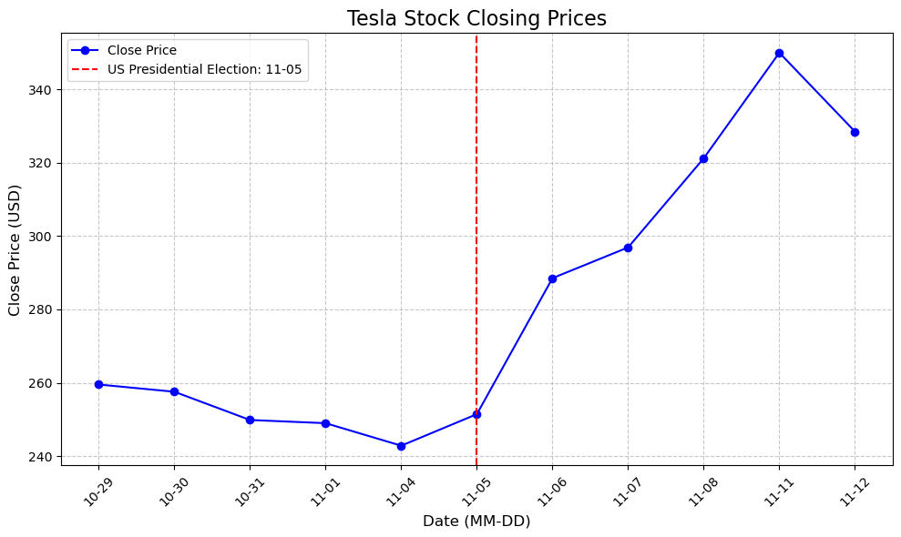

```python
# Plot the line graph
plt.figure(figsize=(10, 6))
plt.plot(df['date'], df['close'], marker='o', color='blue', label="Close Price")
plt.axvline(x='11-05', color='red', linestyle='--', label="US Presidential Election: 11-05")
plt.title("Tesla Stock Closing Prices", fontsize=16)
plt.xlabel("Date (MM-DD)", fontsize=12)
plt.ylabel("Close Price (USD)", fontsize=12)
plt.xticks(rotation=45)
plt.grid(visible=True, linestyle='--', alpha=0.7)
plt.legend()
plt.tight_layout()
plt.show()
```